# Data Analyst Nanodegree Project 1 Analyzing the NYC Subway Dataset

### Section 0. Preparation

```python
import matplotlib
%matplotlib inline
#%matplotlib osx
import pandas
import numpy
from ggplot import *
import statsmodels.api as sm
import statsmodels
import scipy
import matplotlib.pyplot as plt
import math
import seaborn as sns
from datetime import datetime


df = pandas.read_csv('turnstile_data_master_with_weather.csv')
non_rain = df['ENTRIESn_hourly'][df['rain'] == 0]
rain = df['ENTRIESn_hourly'][df['rain'] == 1]
```

### Section 1. Statistical Test

The first question which i asked myself was: Is there any significant difference between number of people enetering subway in rainy and non rainy days. As shown below, data for this particular question isn't normally distributed. So it's suitable to use non-parametric test. In class i've learnt Mann–Whitney U test. Null hypothesis for our two-sided test will be is P(x>y)=0.5, where x - subway crowd in rainy days, y - subway crowd in non rainy days. At first let's check our assumptions about non-gaussian data using Shapiro-Wilk test:

```python
scipy.stats.shapiro(rain)
```

```
(0.4715914726257324, 0.0)
```

```python
scipy.stats.shapiro(non_rain)
```

```
(0.47661787271499634, 0.0)
```

As we can see from Shapiro-Wilk test our data is likely non normal distributed due to extremely low p-value. No let's calculate statistics and p-value for Mann Whitney U test:

```python
t, p_value = scipy.stats.mannwhitneyu(rain, non_rain)
2 * p_value
```

```
0.049999825586979442
```

We've multiplied p-value by two, because scipy returns p-value for one-sided test. This value is less than 0.05 - our significant level, so we should reject the null hypothesis about same mean Entries in rainy or not days. Let examine this data more and look at summary.

```python
"rain mean = {0}, non-rain mean = {1}".format(numpy.mean(rain), numpy.mean(non_rain))
```

```
'rain mean = 1105.44637675, non-rain mean = 1090.27878015'
```

```python
"rain median = {0}, non-rain median = {1}".format(numpy.median(rain), numpy.median(non_rain))
```

```
'rain median = 282.0, non-rain median = 278.0'
```

So it seems that statistical tests is right. In my opinion in shiny days people can walk on the street to work/university. But in rany days it's quite not comfortable, so maybe here is one of the differences. Also i should notice that i used signiificant level 5%.

### Section 2. Linear Regression

In my investigation of givven dataset i was trying to predict how many people will enter subway using different predictors. I've used gradient descent and ols methods for this problem. I want to show prediction using ols method. Optionally i want to notice that i don't want to divide our dataset on train/test. Our response variable will be 'ENTRIESn_hourly'. Our predictior variables will be 'EXITSn_hourly', 'rain', 'fog', 'meantempi'. Let's notice that rain and fog is our dummy variables. I decided to use fog and rain because I thought that when it is very foggy or rainy outside people might decide to use the subway more often. Also i decided to use hour variable because it increase R-squared value.

```python
predictions = []
y = df['ENTRIESn_hourly']
x = df[['EXITSn_hourly' ,'rain', 'fog', 'meantempi', 'Hour']]
x = sm.add_constant(x)
model = sm.OLS(y,x)
results = model.fit()
results.summary()
```

OLS Regression Results

| Dep. Variable: | ENTRIESn_hourly | R-squared: | 0.557 |
| --- | --- | --- | --- |
| Model: | OLS | Adj. R-squared: | 0.557 |
| Method: | Least Squares | F-statistic: | 3.324e+04 |
| Date: | Thu, 15 Jan 2015 | Prob (F-statistic): | 0.00 |
| Time: | 02:43:37 | Log-Likelihood: | -1.1569e+06 |
| No. Observations: | 131951 | AIC: | 2.314e+06 |
| Df Residuals: | 131945 | BIC: | 2.314e+06 |
| Df Model: | 5 |  |  |
| Covariance Type: | nonrobust |  |  |

|  | coef | std err | t | P>\|t\| | [95.0% Conf. Int.] |
| --- | --- | --- | --- | --- | --- |
| const | 338.7101 | 44.285 | 7.648 | 0.000 | 251.913 425.507 |
| EXITSn_hourly | 0.8549 | 0.002 | 395.960 | 0.000 | 0.851 0.859 |
| rain | -16.0728 | 10.372 | -1.550 | 0.121 | -36.402 4.256 |
| fog | 43.0772 | 13.017 | 3.309 | 0.001 | 17.563 68.591 |
| meantempi | -3.4049 | 0.670 | -5.082 | 0.000 | -4.718 -2.092 |
| Hour | 19.7705 | 0.629 | 31.428 | 0.000 | 18.538 21.003 |

| Omnibus: | 109692.515 | Durbin-Watson: | 1.504 |
| --- | --- | --- | --- |
| Prob(Omnibus): | 0.000 | Jarque-Bera (JB): | 25877985.725 |
| Skew: | 3.164 | Prob(JB): | 0.00 |
| Kurtosis: | 71.314 | Cond. No. | 2.28e+04 |

From our summary model we can see that rain variable is not significant for our prediction due to 95% confidence interval contains 0 so we can remove this variable from predictiors in future. In summary of our model we can observe mathematical expectation of coefficients of dummy or non-dummy variables, standart deviation, confidence interval and more different useful statistics.

Coefficient of determination of our model is equal to 0.557. I want to remember that coefficient of determination has next meaning - this is the percentage of variance what explains by our model. We can see that our R-squared low to have accurate predictions.

### Section 3. Visualization

Let's plot our ols prediction results. Let y-axis be 'ENTRIESn_hourly' and x-axis be 'EXITSn_hourly'. Plotting will be done using matplotlib.

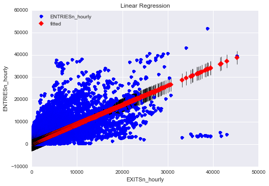

```python
fig, ax = plt.subplots()
statsmodels.graphics.regressionplots.plot_fit(results, 'EXITSn_hourly', ax=ax)
ax.set_ylabel("ENTRIESn_hourly")
ax.set_xlabel("EXITSn_hourly")
ax.set_title("Linear Regression")
plt.show()
```

As we see from plot, we haven't got good model to predict ENTRIESn_hourly on each subway station. Let create visualization which contain two histograms: one of ENTRIESn_hourly for rainy days and one of ENTRIESn_hourly for non-rainy days. For this visualization i've used ggplot.

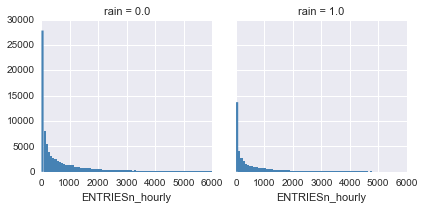

```python
g = sns.FacetGrid(df, col="rain", margin_titles=True)
bins = numpy.linspace(0, 6000, 80)
g.map(plt.hist, 'ENTRIESn_hourly', color="steelblue", bins=bins, lw=0)
```

Let's add more plots and look at subway daily entries/exits with time.

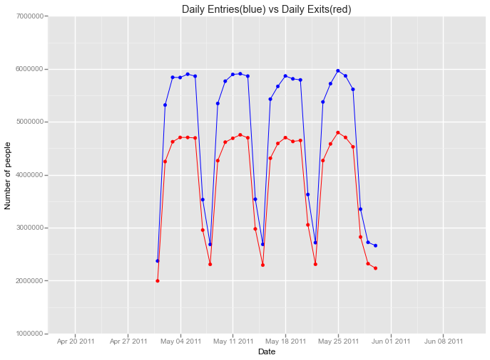

```python
new_df = df[['ENTRIESn_hourly', 'EXITSn_hourly','rain','DATEn']].groupby('DATEn').sum()
new_df.index.name = 'Date'
new_df.reset_index(inplace=True)
new_df['Date'] = pandas.to_datetime(new_df['Date'])
ggplot(new_df, aes(x = 'Date')) + geom_point(aes(y = 'ENTRIESn_hourly', colour = 'blue')) + geom_line(aes(y='ENTRIESn_hourly', colour = 'blue')) +\
geom_point(aes(y = 'EXITSn_hourly', colour = 'red')) + geom_line(aes(y='EXITSn_hourly', colour='red')) + ylab("Number of people") + ggtitle("Daily Entries(blue) vs Daily Exits(red)")
```

Surprisingly, but i my thoutghts are very different from this plot. I was thinking that summary number of Entries & Exits in subway should be near same value, but from plot we can see big difference between this too variables. Also it's very common that less people use subway in weekends.

The last one - let's create density plots of ENTRIESn_hourly depending on weather i.e. fog and rain As in class we will create fog-rain variable at first.

```python
def format_key(fog, rain):
    return '{}fog-{}rain'.format(
        '' if fog else 'no',
        '' if rain else 'no')

fograin = []
for index, row in df.iterrows():
    fograin.append(format_key(row['fog'], row['rain']))
df['fograin'] = pandas.Series(fograin)
```

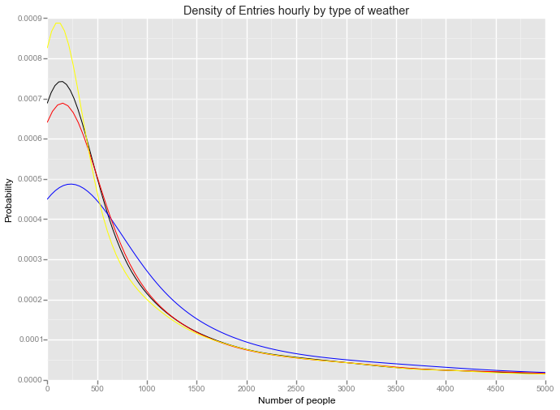

```python
ggplot(df, aes(x='ENTRIESn_hourly', colour='fograin')) + \
    geom_density() + xlim(0, 5000)  + scale_color_manual(values=['blue', 'red','yellow','black']) +\
    xlab("Number of people") + ylab("Probability") + ggtitle("Density of Entries hourly by type of weather")
```

### Section 4. Conclusion

In this first project we partially investigate NYC Subway Dataset. I was trying to answer next question: "Do more people ride the NYC subway when it is raining or when it is not raining?". As part of this investigation i've obtain two samples (rainy and non rainy days). I needed to check zero hypothesis that means of two samples are equal. At first i need to choose statistical test to do this task correctly. I've checked both samples on normality test. Shapiro-Wilk test rejected zero hypothesis about data normality for both samples. So i've choosen Mann-Whitney U test or Wilcoxon rank test, becuase it is non-parametric test (no assumptions about distributions). For our tow samples Mann-Whitney U test has rejected hypothesis. So we can conclude that distribution of the number of entries statistically different between rainy and non rainy days with signifficant level 5%. Let's look at this question from Linear Regression side. As we can see from ols summary, rain coefficient include zero in 95% confidence interval, so from this perespective we can conclude that rain doesn't make any difference in number of people riding the NYC subway. There is still need more investigation to make right decision, but anyway i believe in non-parametric approach more. I've build ols model with not so good r-square equals to 0.557. But it's can be initial solution before more deeper diving in this dataset.

At the end of conclusion i want to citate Mark Twain: "Lies, damned lies, and statistics". Who knows? OLS or Mann-Whitney U test?

### Section 5. Reflection

I've found next potential shortcomings of dataset we use: 1. Daily entries aren't equals to daily exits. Is this a bug? Or maybe i just don't have clear understanding of EXITSn_hourly. I think that entries is how many people enter subway, exits - number of people exiting subway. I'm sure this variables should be daily equal. 2. Just one month of data. This implies low variablity of tempreture and other interesting features, so they might be no so important at May, but can be extremely useful in winter.

Some notes about application of Linear Regression to our dataset: 1. It's clear to see from figure that our data is seasonal. So we might include seasonal characteristics to predict ENTRIESn_hourly. But classic linear regression doesn't take seasonality into account.

Last notes about statistical tests: 1. It's really fantastic to know about parametric and non-parametric statistical tests. But i think i should use one more non-parametric test to approve my results.